# EasyVisa Project

### Hyperparameter tuning for Decision Tree

```python
# Choose the type of classifier.
dtree_estimator = DecisionTreeClassifier(random_state=1)

# Grid of parameters to choose from
parameters = {
    "max_depth": np.arange(2, 30),
    "min_samples_leaf": [1, 2, 5, 7, 10],
    "max_leaf_nodes": [2, 3, 5, 10, 15],
    "min_impurity_decrease": [0.0001, 0.001, 0.01, 0.1],
}

# Type of scoring used to compare parameter combinations
scorer = metrics.make_scorer(metrics.f1_score)

# Run the grid search
grid_obj = GridSearchCV(dtree_estimator, parameters, scoring=scorer, n_jobs=-1)
grid_obj = grid_obj.fit(X_train, y_train)

# Set the clf to the best combination of parameters
dtree_estimator = grid_obj.best_estimator_

# Fit the best algorithm to the data.
dtree_estimator.fit(X_train, y_train)
```

```
DecisionTreeClassifier(max_depth=5, max_leaf_nodes=15,
                       min_impurity_decrease=0.0001, random_state=1)
```

#### Checking training performance on tuned Decision tree

```
Training performance:
    Accuracy    Recall  Precision        F1
0  0.737834  0.916226   0.747961  0.823587
```

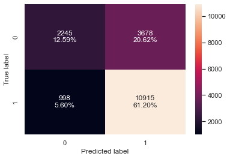

```python
# Calculating different metrics
dtree_estimator_model_train_perf = model_performance_classification_sklearn(
    dtree_estimator, X_train, y_train
)
print("Training performance:\n", dtree_estimator_model_train_perf)
# Creating confusion matrix
confusion_matrix_sklearn(dtree_estimator, X_train, y_train)
```

#### Checking testing performance on tuned Decision tree

```
Testing performance:
    Accuracy    Recall  Precision        F1
0  0.728938  0.914006   0.740753  0.818309
```

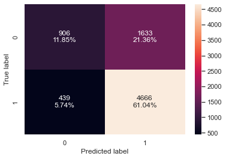

```python
dtree_estimator_model_test_perf = model_performance_classification_sklearn(
    dtree_estimator, X_test, y_test
)
print("Testing performance:\n", dtree_estimator_model_test_perf)
# Creating confusion matrix
confusion_matrix_sklearn(dtree_estimator, X_test, y_test)
```

#### Observations:

- Both training and testing performance are consistent, hence we can say tuned decision tree is giving generalized performance.
- However, even though the recall is ~91%, the precision is ~74% and hence the f1 score is ~81% on test data.
- We can observe the model is performing good predicting the certified cases however not doing well predicting the denied cases
- Let's build other models and see if we have any other better model for the business problem.

#### Checking feature importance for tuned Decision tree

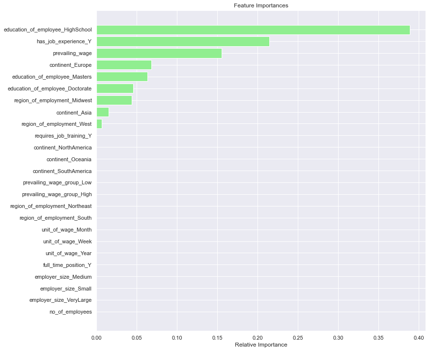

```python
model_feature_importances(dtree_estimator, X_train)
```

#### Observations:

For decision tree we can observe below features as important features -

- education of employee
- some level of region of employment
- some level of continent
- prior job experience
- prevailing wage

## Building- Bagging Classifier

#### Fitting the Bagging classifier model with default parameters

```python
# Fitting the model
bagging_classifier = BaggingClassifier(random_state=1)
bagging_classifier.fit(X_train, y_train)
```

```
BaggingClassifier(random_state=1)
```

#### Checking the training performance

```
   Accuracy    Recall  Precision        F1
0  0.982003  0.983296   0.989692  0.986484
```

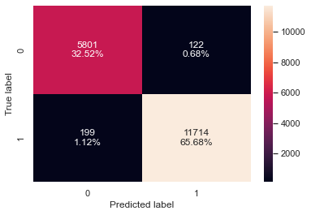

```python
# Calculating different metrics
bagging_classifier_model_train_perf = model_performance_classification_sklearn(
    bagging_classifier, X_train, y_train
)
print(bagging_classifier_model_train_perf)
# Creating confusion matrix
confusion_matrix_sklearn(bagging_classifier, X_train, y_train)
```

#### Checking the testing performance

```
   Accuracy    Recall  Precision        F1
0  0.690476  0.767483   0.768687  0.768085
```

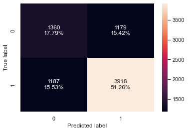

```python
# Calculating different metrics
bagging_classifier_model_test_perf = model_performance_classification_sklearn(
    bagging_classifier, X_test, y_test
)
print(bagging_classifier_model_test_perf)
# Creating confusion matrix
confusion_matrix_sklearn(bagging_classifier, X_test, y_test)
```

#### Observations:

- Bagging classifier model on training set giving f1 score as ~98%, however in testing data the f1 score has dropped to ~76%.
- We can say this model with Bagging classifier is also overfit.
- We will try to tune the model and see if that reduce the overfit and generalize the model, with better f1 score in test set.

### Hyperparameter tuning for Bagging Classifier

```python
# Choose the type of classifier.
bagging_estimator_tuned = BaggingClassifier(random_state=1)

# Grid of parameters to choose from
parameters = {
    "max_samples": [0.7, 0.8, 0.9, 1],
    "max_features": [0.7, 0.8, 0.9, 1],
    "n_estimators": [10, 20, 30, 40, 50],
}

# Type of scoring used to compare parameter combinations
scorer = metrics.make_scorer(metrics.f1_score)

# Run the grid search
grid_obj = GridSearchCV(bagging_estimator_tuned, parameters, scoring=scorer, cv=5)
grid_obj = grid_obj.fit(X_train, y_train)

# Set the clf to the best combination of parameters
bagging_estimator_tuned = grid_obj.best_estimator_

# Fit the best algorithm to the data.
bagging_estimator_tuned.fit(X_train, y_train)
```

```
BaggingClassifier(max_features=0.7, max_samples=0.7, n_estimators=50,
                  random_state=1)
```

#### Checking training performance on tuned Bagging Classifier

```
   Accuracy    Recall  Precision        F1
0  0.986208  0.998573   0.981113  0.989766
```

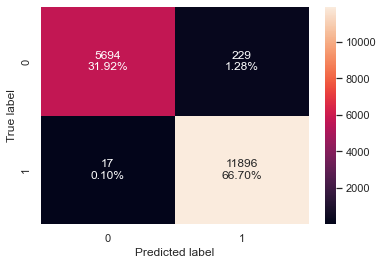

```python
# Calculating different metrics
bagging_estimator_tuned_model_train_perf = model_performance_classification_sklearn(
    bagging_estimator_tuned, X_train, y_train
)
print(bagging_estimator_tuned_model_train_perf)
# Creating confusion matrix
confusion_matrix_sklearn(bagging_estimator_tuned, X_train, y_train)
```

#### Checking testing performance on tuned Bagging Classifier

```
   Accuracy    Recall  Precision        F1
0  0.724228  0.883839   0.748631  0.810636
```

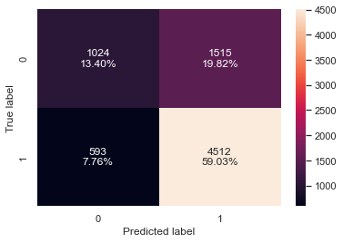

```python
# Calculating different metrics
bagging_estimator_tuned_model_test_perf = model_performance_classification_sklearn(
    bagging_estimator_tuned, X_test, y_test
)
print(bagging_estimator_tuned_model_test_perf)
# Creating confusion matrix
confusion_matrix_sklearn(bagging_estimator_tuned, X_test, y_test)
```

#### Observations:

- Even though in tuned model there is slight improved in performance from default Bagging Classifier, however the model is still overfit.
- The reason we are saying this as an overfit model as the training set gives us a f1 score of ~98% however in testing set it's ~81%, recall is also behaving in the same manner.
- This model is not suitable for production as on unseen data it's not stable, we are not going to check the feature importance for this.
- Let's build other model to see if we can have better generalized model with higher f1 score.

## Building - Random Forest Classifier

#### Fitting the RandomForest Classifier model with default parameters

```python
# Fitting the model
rf_estimator = RandomForestClassifier(random_state=1)
rf_estimator.fit(X_train, y_train)
```

```
RandomForestClassifier(random_state=1)
```

#### Checking the training performance

```
Training performance:
    Accuracy  Recall  Precision   F1
0       1.0     1.0        1.0  1.0
```

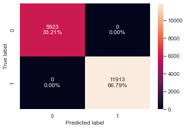

```python
# Calculating different metrics
rf_estimator_model_train_perf = model_performance_classification_sklearn(
    rf_estimator, X_train, y_train
)
print("Training performance:\n", rf_estimator_model_train_perf)
# Creating confusion matrix
confusion_matrix_sklearn(rf_estimator, X_train, y_train)
```

#### Checking the testing performance

```
Testing performance:
    Accuracy    Recall  Precision        F1
0  0.706698  0.817434    0.76108  0.788251
```

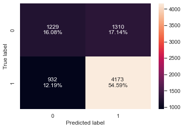

```python
# Calculating different metrics
rf_estimator_model_test_perf = model_performance_classification_sklearn(
    rf_estimator, X_test, y_test
)
print("Testing performance:\n", rf_estimator_model_test_perf)
# Creating confusion matrix
confusion_matrix_sklearn(rf_estimator, X_test, y_test)
```

#### Observations:

- Random forest model on training set is giving 100% of recall and precision.
- The model performance on testing set is poor compared to training set, f1 score is ~78%. Hence we can say that this model is overfitted.
- Let's try to tune the model and see if we can reduce overfitiing and increase performance.

### Hyperparameter tuning for RandomForest Classifier

```python
# Choose the type of classifier.
rf_tuned = RandomForestClassifier(random_state=1, bootstrap=True)

parameters = {
    "max_depth": list(np.arange(5, 30, 5)) + [None],
    "max_features": ["sqrt", "log2", None],
    "min_samples_leaf": np.arange(1, 15, 5),
    "min_samples_split": np.arange(2, 20, 5),
    "n_estimators": np.arange(10, 110, 10),
}


# Type of scoring used to compare parameter combinations
scorer = metrics.make_scorer(metrics.f1_score)

# Run the grid search
grid_obj = GridSearchCV(rf_tuned, parameters, scoring=scorer, cv=5, n_jobs=-1)
grid_obj = grid_obj.fit(X_train, y_train)

# Set the clf to the best combination of parameters
rf_tuned = grid_obj.best_estimator_

# Fit the best algorithm to the data.
rf_tuned.fit(X_train, y_train)
```

```
RandomForestClassifier(max_depth=10, max_features='log2', min_samples_split=17,
                       n_estimators=20, random_state=1)
```

#### Checking training performance on RandomForest tuned model

```
Training performance:
    Accuracy    Recall  Precision        F1
0  0.758354  0.918828   0.766044  0.835509
```

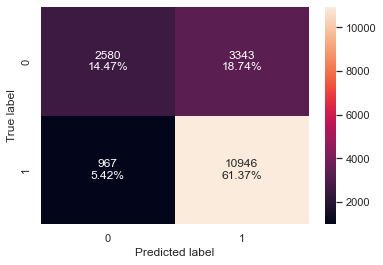

```python
# Calculating different metrics
rf_tuned_model_train_perf = model_performance_classification_sklearn(
    rf_tuned, X_train, y_train
)
print("Training performance:\n", rf_tuned_model_train_perf)
# Creating confusion matrix
confusion_matrix_sklearn(rf_tuned, X_train, y_train)
```

#### Checking test performance on RandomForest tuned model

```
Testing performance:
    Accuracy    Recall  Precision        F1
0  0.737179  0.909109   0.750242  0.822071
```

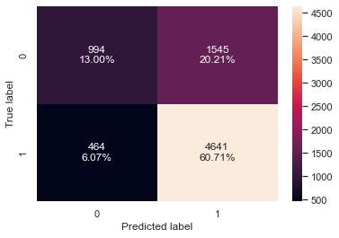

```python
# Calculating different metrics
rf_tuned_model_test_perf = model_performance_classification_sklearn(
    rf_tuned, X_test, y_test
)
print("Testing performance:\n", rf_tuned_model_test_perf)
# Creating confusion matrix
confusion_matrix_sklearn(rf_tuned, X_test, y_test)
```

#### Observations:

- The tuned RamdomForest Classifier model is performing more generlized way than default RandomForest model.
- The recall and f1 score are smilar in both training and testing set. f1 score is ~82% on testing set compared to ~83% in training.
- Let's see the feature importance of this model, as this model has potential to be used in production for prediction.

#### Checking Feature importance for tuned RandomForest classifier model

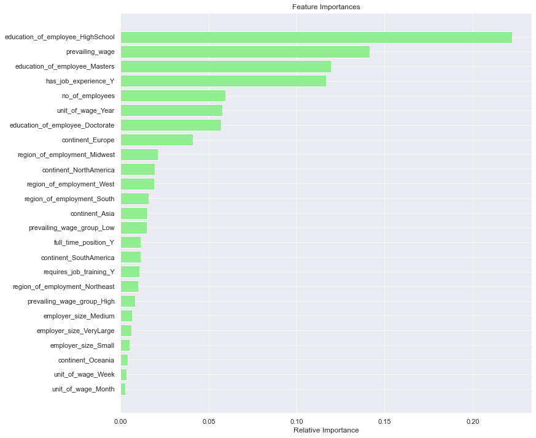

```python
model_feature_importances(rf_tuned, X_train)
```

#### Observations:

- We can observe all the features are shows some importance for tuned RandomForest classifier model.
- Top few top features are some level of education of employee, prevailing wage, prior job experience.
- We will explore further with boosting models and then finally decide on the final solution model for business.

## Building - Adaboost Classifier

#### Fitting Adaboost classifier with default parameters

```python
# Fitting the model
ab_classifier = AdaBoostClassifier(random_state=1)
ab_classifier.fit(X_train, y_train)
```

```
AdaBoostClassifier(random_state=1)
```

#### Checking performance on training

```
   Accuracy    Recall  Precision        F1
0  0.737778  0.884244   0.761567  0.818334
```

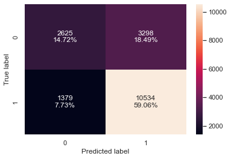

```python
# Calculating different metrics
ab_classifier_model_train_perf = model_performance_classification_sklearn(
    ab_classifier, X_train, y_train
)
print(ab_classifier_model_train_perf)
# Creating confusion matrix
confusion_matrix_sklearn(ab_classifier, X_train, y_train)
```

#### Checking testing performance

```
   Accuracy    Recall  Precision        F1
0  0.736264  0.884623   0.759886  0.817524
```

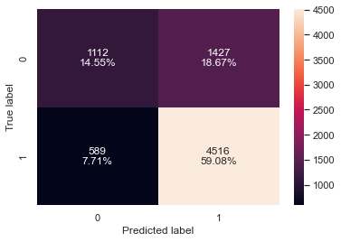

```python
# Calculating different metrics
ab_classifier_model_test_perf = model_performance_classification_sklearn(
    ab_classifier, X_test, y_test
)
print(ab_classifier_model_test_perf)
# Creating confusion matrix
confusion_matrix_sklearn(ab_classifier, X_test, y_test)
```

#### Observations:

- Training and testing performance is similar and very close to each other, with f1 score ~81%.
- The model is not overfitting, hence we can say the model is generalized and stable.
- Let's see if hyperparameter tune will improve the performance further

### Hyperparameter tuning on Adaboost Classifier

```python
# Choose the type of classifier.
abc_tuned = AdaBoostClassifier(random_state=1)

# Grid of parameters to choose from
parameters = {
    # Let's try different max_depth for base_estimator
    "base_estimator": [
        DecisionTreeClassifier(max_depth=1),
        DecisionTreeClassifier(max_depth=2),
        DecisionTreeClassifier(max_depth=3),
    ],
    "n_estimators": np.arange(10, 110, 10),
    "learning_rate": np.arange(0.1, 2, 0.1),
}

# Type of scoring used to compare parameter  combinations
scorer = metrics.make_scorer(metrics.f1_score)

# Run the grid search
grid_obj = GridSearchCV(abc_tuned, parameters, scoring=scorer, cv=5)
grid_obj = grid_obj.fit(X_train, y_train)

# Set the clf to the best combination of parameters
abc_tuned = grid_obj.best_estimator_

# Fit the best algorithm to the data.
abc_tuned.fit(X_train, y_train)
```

```
AdaBoostClassifier(base_estimator=DecisionTreeClassifier(max_depth=3),
                   learning_rate=0.1, random_state=1)
```

#### Checking training performance on tuned Adaboost model

```
   Accuracy    Recall  Precision        F1
0  0.749776  0.892554   0.769615  0.826538
```

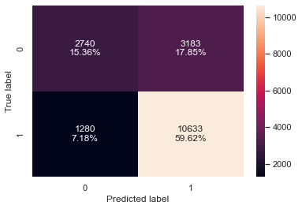

```python
# Calculating different metrics
abc_tuned_model_train_perf = model_performance_classification_sklearn(
    abc_tuned, X_train, y_train
)
print(abc_tuned_model_train_perf)
# Creating confusion matrix
confusion_matrix_sklearn(abc_tuned, X_train, y_train)
```

#### Checking testing performance on tuned Adaboost model

```
   Accuracy    Recall  Precision        F1
0  0.741889  0.890695   0.762664  0.821722
```

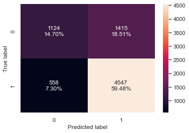

```python
# Calculating different metrics
abc_tuned_model_test_perf = model_performance_classification_sklearn(
    abc_tuned, X_test, y_test
)
print(abc_tuned_model_test_perf)
# Creating confusion matrix
confusion_matrix_sklearn(abc_tuned, X_test, y_test)
```

#### Observations:

- From the default adaboost model the tuned model shows slightly better performance, default adaboost had ~81% f1 score and tuned adaboost has f1 score as ~82%
- Both training and testing set performance is consistent and similar, hence model is not overfitted and pretty generalized.
- Let's also check how Gradient boost model performs

#### Checking the feature importances for tuned adaboost model

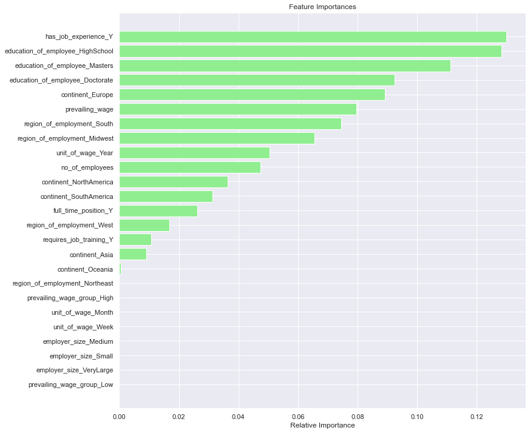

```python
model_feature_importances(abc_tuned, X_train)
```

#### Observations:

- Prior job experience and education of employee are the most important features.
- Prevailing wage, continent, unit of wage, region of employment, requires job training shows some importance for this model.

## Building - GradientBoosting Classifier

#### Fitting GradientBoosting Classifier with default parameters

```python
# Fitting the model
gb_classifier = GradientBoostingClassifier(random_state=1)
gb_classifier.fit(X_train, y_train)
```

```
GradientBoostingClassifier(random_state=1)
```

#### Checking training performance

```
Training performance:
    Accuracy    Recall  Precision        F1
0   0.75684  0.877193   0.784299  0.828149
```

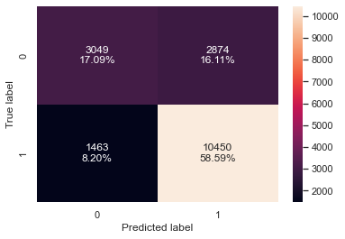

```python
# Calculating different metrics
gb_classifier_model_train_perf = model_performance_classification_sklearn(
    gb_classifier, X_train, y_train
)
print("Training performance:\n", gb_classifier_model_train_perf)
# Creating confusion matrix
confusion_matrix_sklearn(gb_classifier, X_train, y_train)
```

#### Checking testing performance

```
Testing performance:
    Accuracy    Recall  Precision        F1
0  0.745814  0.872086    0.77534  0.820872
```

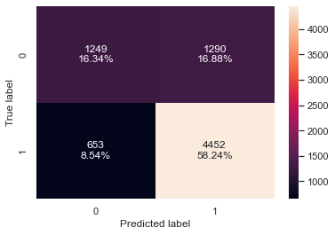

```python
# Calculating different metrics
gb_classifier_model_test_perf = model_performance_classification_sklearn(
    gb_classifier, X_test, y_test
)
print("Testing performance:\n", gb_classifier_model_test_perf)
# Creating confusion matrix
confusion_matrix_sklearn(gb_classifier, X_test, y_test)
```

#### Observations:

- Both training and testing set performance are decent and close to each other, model is not overfitted.
- Recall ~87% and f1 score is ~82% for Gradient boost model with default parameter.
- Let's see tuning hyperparameter will increase the performance further.

### Hyperparameter tuning for GradientBoosting classifier

```python
# Choose the type of classifier.
gbc_tuned = GradientBoostingClassifier(
    init=AdaBoostClassifier(random_state=1), random_state=1
)

# Grid of parameters to choose from
parameters = {
    "n_estimators": [100, 150, 200, 250],
    "subsample": [0.8, 0.9, 1],
    "max_features": [0.7, 0.8, 0.9, 1],
}

# Type of scoring used to compare parameter combinations
scorer = metrics.make_scorer(metrics.f1_score)

# Run the grid search
grid_obj = GridSearchCV(gbc_tuned, parameters, scoring=scorer, cv=5)
grid_obj = grid_obj.fit(X_train, y_train)

# Set the clf to the best combination of parameters
gbc_tuned = grid_obj.best_estimator_

# Fit the best algorithm to the data.
gbc_tuned.fit(X_train, y_train)
```

```
GradientBoostingClassifier(init=AdaBoostClassifier(random_state=1),
                           max_features=0.8, n_estimators=150, random_state=1,
                           subsample=1)
```

#### Checking training performance on tuned GradientBoosting model

```
Training performance:
    Accuracy    Recall  Precision        F1
0  0.758746  0.877193   0.786305  0.829266
```

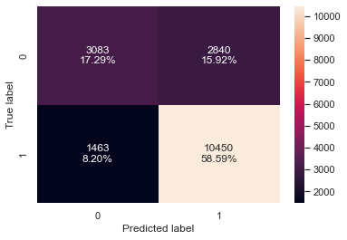

```python
# Calculating different metrics
gbc_tuned_model_train_perf = model_performance_classification_sklearn(
    gbc_tuned, X_train, y_train
)
print("Training performance:\n", gbc_tuned_model_train_perf)
# Creating confusion matrix
confusion_matrix_sklearn(gbc_tuned, X_train, y_train)
```

#### Checking testing performance on tuned GradientBoosting model

```
Testing performance:
    Accuracy    Recall  Precision        F1
0  0.748038  0.872674   0.777351  0.822259
```

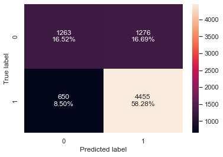

```python
# Calculating different metrics
gbc_tuned_model_test_perf = model_performance_classification_sklearn(
    gbc_tuned, X_test, y_test
)
print("Testing performance:\n", gbc_tuned_model_test_perf)
# Creating confusion matrix
confusion_matrix_sklearn(gbc_tuned, X_test, y_test)
```

#### Observations:

- Both training and testing set performance on tuned Gradient boost models looks similar, there is not much performance improvement as well from the default parameter GradientBoosting model
- The f1 score for tuned model is ~82% which is similar as default parameter model
- Let's check the feature importances and further also check the xgboost model if we can create a better model

#### Checking feature importances for tuned Gradientboosting model

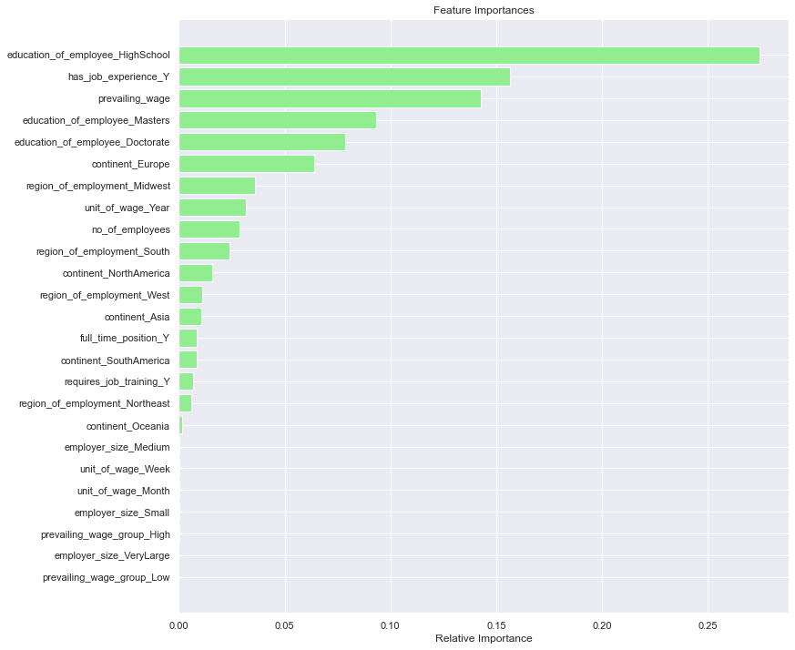

```python
model_feature_importances(gbc_tuned, X_train)
```

#### Observations:

- We can observe education of employee and prevailing wage are important features across all models we are evaluating.
- Some other important features in tuned GradientBoosting model are as prior job experience, continent, no of employees, region of emplyment

## Building - XGBoost Classifier

#### Fitting the model with default parameter

```python
# Fitting the model
xgb_classifier = XGBClassifier(random_state=1, eval_metric="logloss")
xgb_classifier.fit(X_train, y_train)
```

```
XGBClassifier(base_score=0.5, booster='gbtree', colsample_bylevel=1,
              colsample_bynode=1, colsample_bytree=1, eval_metric='logloss',
              gamma=0, gpu_id=-1, importance_type='gain',
              interaction_constraints='', learning_rate=0.300000012,
              max_delta_step=0, max_depth=6, min_child_weight=1, missing=nan,
              monotone_constraints='()', n_estimators=100, n_jobs=8,
              num_parallel_tree=1, random_state=1, reg_alpha=0, reg_lambda=1,
              scale_pos_weight=1, subsample=1, tree_method='exact',
              validate_parameters=1, verbosity=None)
```

#### Checking training performance

```
Training performance:
    Accuracy    Recall  Precision        F1
0  0.825746  0.922773   0.834003  0.876146
```

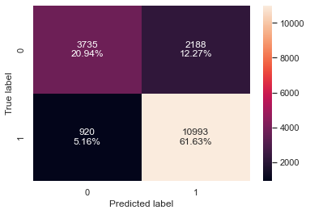

```python
# Calculating different metrics
xgb_classifier_model_train_perf = model_performance_classification_sklearn(
    xgb_classifier, X_train, y_train
)
print("Training performance:\n", xgb_classifier_model_train_perf)
# Creating confusion matrix
confusion_matrix_sklearn(xgb_classifier, X_train, y_train)
```

#### Checking testing performance

```
Testing performance:
    Accuracy    Recall  Precision        F1
0  0.736002  0.861117   0.770552  0.813321
```

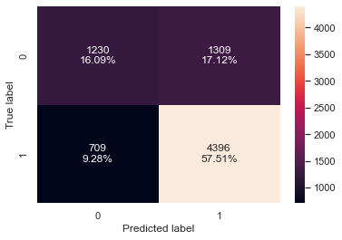

```python
# Calculating different metrics
xgb_classifier_model_test_perf = model_performance_classification_sklearn(
    xgb_classifier, X_test, y_test
)
print("Testing performance:\n", xgb_classifier_model_test_perf)
# Creating confusion matrix
confusion_matrix_sklearn(xgb_classifier, X_test, y_test)
```

#### Observations:

- We can observe the performance is getting dropped in testing set from training. Model shows signs of overfitting and not stable for unseen data.
- The f1 score ~87% got dropped to ~81%, recall has also dropped

### Hyperparameter tuning for XGBoost model

```python
# Choose the type of classifier.
xgb_tuned = XGBClassifier(random_state=1, eval_metric="logloss")

# Grid of parameters to choose from
parameters = {
    "n_estimators": [10, 30, 50],
    "scale_pos_weight": [1, 2, 5],
    "subsample": [0.7, 0.9, 1],
    "learning_rate": [0.05, 0.1, 0.2],
    "colsample_bytree": [0.7, 0.9, 1],
    "colsample_bylevel": [0.5, 0.7, 1],
}

# Type of scoring used to compare parameter combinations
scorer = metrics.make_scorer(metrics.f1_score)

# Run the grid search
grid_obj = GridSearchCV(xgb_tuned, parameters, scoring=scorer, cv=5)
grid_obj = grid_obj.fit(X_train, y_train)

# Set the clf to the best combination of parameters
xgb_tuned = grid_obj.best_estimator_

# Fit the best algorithm to the data.
xgb_tuned.fit(X_train, y_train)
```

```
XGBClassifier(base_score=0.5, booster='gbtree', colsample_bylevel=0.5,
              colsample_bynode=1, colsample_bytree=0.9, eval_metric='logloss',
              gamma=0, gpu_id=-1, importance_type='gain',
              interaction_constraints='', learning_rate=0.1, max_delta_step=0,
              max_depth=6, min_child_weight=1, missing=nan,
              monotone_constraints='()', n_estimators=10, n_jobs=8,
              num_parallel_tree=1, random_state=1, reg_alpha=0, reg_lambda=1,
              scale_pos_weight=1, subsample=1, tree_method='exact',
              validate_parameters=1, verbosity=None)
```

#### Checking performance of training in tuned XGBoost model

```
Training performance:
    Accuracy    Recall  Precision        F1
0   0.74871  0.917233   0.757609  0.829815
```

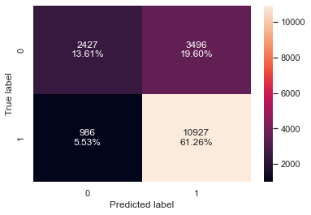

```python
# Calculating different metrics
xgb_tuned_model_train_perf = model_performance_classification_sklearn(
    xgb_tuned, X_train, y_train
)
print("Training performance:\n", xgb_tuned_model_train_perf)
# Creating confusion matrix
confusion_matrix_sklearn(xgb_tuned, X_train, y_train)
```

#### Checking performance on testing in tuned XGBoost model

```
Testing performance:
    Accuracy    Recall  Precision        F1
0  0.737964  0.914789   0.748637  0.823415
```

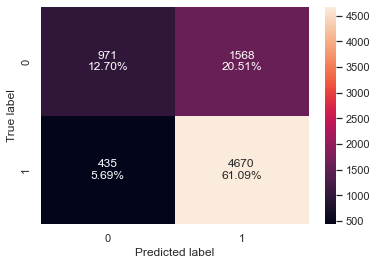

```python
# Calculating different metrics
xgb_tuned_model_test_perf = model_performance_classification_sklearn(
    xgb_tuned, X_test, y_test
)
print("Testing performance:\n", xgb_tuned_model_test_perf)
# Creating confusion matrix
confusion_matrix_sklearn(xgb_tuned, X_test, y_test)
```

#### Observations:

- Tuned XGBoost model doesn't show sign of overfitting as both training and test set performances are consistent.
- However we don't see much improvement than any other models, the f1 score is ~82%, which we have seen for other tuned models as well.
- Let's now compare performances of all models we have created and decide on a final model for the solution

#### Checking feature importances for tuned XGBoost model

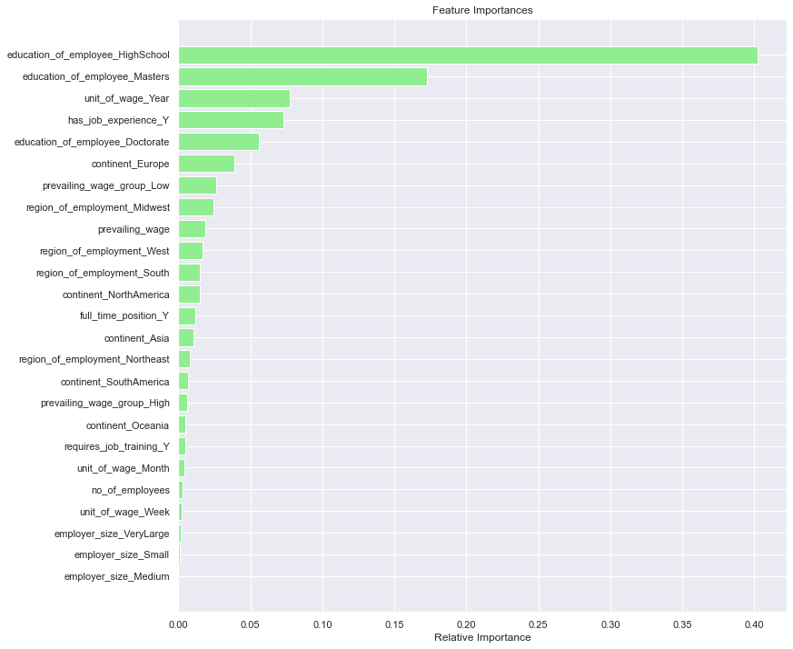

```python
model_feature_importances(xgb_tuned, X_train)
```

#### Observations:

- eductaion of employee, unit of wage, prior job experience, continet, prevailing wage group, prevailing wage, are some of the important features for XGBoost model

## Building - Stacking Classfier

- Let's use tuned random forest, gradient boosting, decision tree as base estimator and XGboost as final estimator and build a Stacking Classifier and see if that improves the performance further

```python
estimators = [
    ("Random Forest", rf_tuned),
    ("Gradient Boosting", gbc_tuned),
    ("Decision Tree", dtree_estimator),
]

final_estimator = xgb_tuned

stacking_classifier = StackingClassifier(
    estimators=estimators, final_estimator=final_estimator
)

stacking_classifier.fit(X_train, y_train)
```

```
StackingClassifier(estimators=[('Random Forest',
                                RandomForestClassifier(max_depth=10,
                                                       max_features='log2',
                                                       min_samples_split=17,
                                                       n_estimators=20,
                                                       random_state=1)),
                               ('Gradient Boosting',
                                GradientBoostingClassifier(init=AdaBoostClassifier(random_state=1),
                                                           max_features=0.8,
                                                           n_estimators=150,
                                                           random_state=1,
                                                           subsample=1)),
                               ('Decision Tree',
                                DecisionTreeClassifier(max_...
                                                 eval_metric='logloss', gamma=0,
                                                 gpu_id=-1,
                                                 importance_type='gain',
                                                 interaction_constraints='',
                                                 learning_rate=0.1,
                                                 max_delta_step=0, max_depth=6,
                                                 min_child_weight=1,
                                                 missing=nan,
                                                 monotone_constraints='()',
                                                 n_estimators=10, n_jobs=8,
                                                 num_parallel_tree=1,
                                                 random_state=1, reg_alpha=0,
                                                 reg_lambda=1,
                                                 scale_pos_weight=1,
                                                 subsample=1,
                                                 tree_method='exact',
                                                 validate_parameters=1,
                                                 verbosity=None))
```

#### Checking the training performance

```
Training performance:
    Accuracy   Recall  Precision        F1
0  0.760092  0.87224    0.79031  0.829257
```

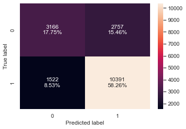

```python
# Calculating different metrics
stacking_classifier_model_train_perf = model_performance_classification_sklearn(
    stacking_classifier, X_train, y_train
)
print("Training performance:\n", stacking_classifier_model_train_perf)
# Creating confusion matrix
confusion_matrix_sklearn(stacking_classifier, X_train, y_train)
```

#### Checking the testing performance

```
Testing performance:
    Accuracy    Recall  Precision        F1
0  0.746991  0.866993   0.779088  0.820693
```

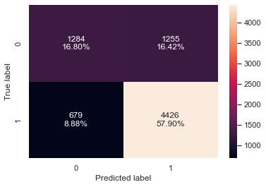

```python
# Calculating different metrics
stacking_classifier_model_test_perf = model_performance_classification_sklearn(
    stacking_classifier, X_test, y_test
)
print("Testing performance:\n", stacking_classifier_model_test_perf)
# Creating confusion matrix
confusion_matrix_sklearn(stacking_classifier, X_test, y_test)
```

#### Observations:

- The Stacking classifier doesn't show sign of overfitting as training and testing performances are consistent and almost similar
- Even though the f1 score of Stacking classifier is almost similar to other genaralized model but the recall is dropped from those models.
- So tuned XGboost still shows better performance.

## Model Performance Comparison and Conclusions

### Training set performance comparison for all models

- Creating a dataframe with all results for better readability and representation

```python
# training performance comparison

models_train_comp_df = pd.concat(
    [
        d_tree_model_train_perf.T,
        dtree_estimator_model_train_perf.T,
        rf_estimator_model_train_perf.T,
        rf_tuned_model_train_perf.T,
        bagging_classifier_model_train_perf.T,
        bagging_estimator_tuned_model_train_perf.T,
        ab_classifier_model_train_perf.T,
        abc_tuned_model_train_perf.T,
        gb_classifier_model_train_perf.T,
        gbc_tuned_model_train_perf.T,
        xgb_classifier_model_train_perf.T,
        xgb_tuned_model_train_perf.T,
        stacking_classifier_model_train_perf.T,
    ],
    axis=1,
)
models_train_comp_df.columns = [
    "Decision Tree",
    "Decision Tree Estimator",
    "Random Forest Estimator",
    "Random Forest Tuned",
    "Bagging Classifier",
    "Bagging Estimator Tuned",
    "Adaboost Classifier",
    "Adabosst Classifier Tuned",
    "Gradient Boost Classifier",
    "Gradient Boost Classifier Tuned",
    "XGBoost Classifier",
    "XGBoost Classifier Tuned",
    "Stacking Classifier",
]
print("Training performance comparison:")
models_train_comp_df
```

```
Training performance comparison:
```

|  | Decision Tree | Decision Tree Estimator | Random Forest Estimator | Random Forest Tuned | Bagging Classifier | Bagging Estimator Tuned | Adaboost Classifier | Adabosst Classifier Tuned | Gradient Boost Classifier | Gradient Boost Classifier Tuned | XGBoost Classifier | XGBoost Classifier Tuned | Stacking Classifier |
| --- | --- | --- | --- | --- | --- | --- | --- | --- | --- | --- | --- | --- | --- |
| Accuracy | 1.0 | 0.737834 | 1.0 | 0.758354 | 0.982003 | 0.986208 | 0.737778 | 0.749776 | 0.756840 | 0.758746 | 0.825746 | 0.748710 | 0.760092 |
| Recall | 1.0 | 0.916226 | 1.0 | 0.918828 | 0.983296 | 0.998573 | 0.884244 | 0.892554 | 0.877193 | 0.877193 | 0.922773 | 0.917233 | 0.872240 |
| Precision | 1.0 | 0.747961 | 1.0 | 0.766044 | 0.989692 | 0.981113 | 0.761567 | 0.769615 | 0.784299 | 0.786305 | 0.834003 | 0.757609 | 0.790310 |
| F1 | 1.0 | 0.823587 | 1.0 | 0.835509 | 0.986484 | 0.989766 | 0.818334 | 0.826538 | 0.828149 | 0.829266 | 0.876146 | 0.829815 | 0.829257 |

### Testing set performance comparison for all models

- Creating a dataframe with all results for better readability and representation

```python
# testing performance comparison

models_test_comp_df = pd.concat(
    [
        d_tree_model_test_perf.T,
        dtree_estimator_model_test_perf.T,
        rf_estimator_model_test_perf.T,
        rf_tuned_model_test_perf.T,
        bagging_classifier_model_test_perf.T,
        bagging_estimator_tuned_model_test_perf.T,
        ab_classifier_model_test_perf.T,
        abc_tuned_model_test_perf.T,
        gb_classifier_model_test_perf.T,
        gbc_tuned_model_test_perf.T,
        xgb_classifier_model_test_perf.T,
        xgb_tuned_model_test_perf.T,
        stacking_classifier_model_test_perf.T,
    ],
    axis=1,
)
models_test_comp_df.columns = [
    "Decision Tree",
    "Decision Tree Estimator",
    "Random Forest Estimator",
    "Random Forest Tuned",
    "Bagging Classifier",
    "Bagging Estimator Tuned",
    "Adaboost Classifier",
    "Adabosst Classifier Tuned",
    "Gradient Boost Classifier",
    "Gradient Boost Classifier Tuned",
    "XGBoost Classifier",
    "XGBoost Classifier Tuned",
    "Stacking Classifier",
]
print("Testing performance comparison:")
models_test_comp_df
```

```
Testing performance comparison:
```

|  | Decision Tree | Decision Tree Estimator | Random Forest Estimator | Random Forest Tuned | Bagging Classifier | Bagging Estimator Tuned | Adaboost Classifier | Adabosst Classifier Tuned | Gradient Boost Classifier | Gradient Boost Classifier Tuned | XGBoost Classifier | XGBoost Classifier Tuned | Stacking Classifier |
| --- | --- | --- | --- | --- | --- | --- | --- | --- | --- | --- | --- | --- | --- |
| Accuracy | 0.645997 | 0.728938 | 0.706698 | 0.737179 | 0.690476 | 0.724228 | 0.736264 | 0.741889 | 0.745814 | 0.748038 | 0.736002 | 0.737964 | 0.746991 |
| Recall | 0.734574 | 0.914006 | 0.817434 | 0.909109 | 0.767483 | 0.883839 | 0.884623 | 0.890695 | 0.872086 | 0.872674 | 0.861117 | 0.914789 | 0.866993 |
| Precision | 0.735150 | 0.740753 | 0.761080 | 0.750242 | 0.768687 | 0.748631 | 0.759886 | 0.762664 | 0.775340 | 0.777351 | 0.770552 | 0.748637 | 0.779088 |
| F1 | 0.734862 | 0.818309 | 0.788251 | 0.822071 | 0.768085 | 0.810636 | 0.817524 | 0.821722 | 0.820872 | 0.822259 | 0.813321 | 0.823415 | 0.820693 |

#### Observations:

- Most of the models has overfitted on the training data, tuning helped with overfitting except bagging classifier where even after hyperparameter tuning we have noticed the model overfitted.
- Among all these models tuned XGBoost gave the highest f1 score in test data with ~82.3% and recall score ~91.4% which means close to 91% of applicants are correctly identified for whom the visa will be granted, and model performed well and in generalized manner, as the training and testing performances are pretyy stable and similar.
- So we can conclude **XGBoost Tuned (xgb_tuned)** is the best model and we can use this model for this business problem to predict if VISA will be certified or denied based on profiles of applicant.